## Lab 2

Welcome to the second lab of the AIML! In addition to implementing code, there will be questions that you must answer which relate to the lab and your implementation. Each question you will answer is preceded by a **'Question X'** header. Carefully read each question and provide you answer or code in the following textboxes with **'Answer:'** header. Your lab submission will be evaluated based on your answers to each of the questions and the implementation you provide.

# Every question is of 1 mark.

## Hypothesis Testing

The purpose of the test is to tell if there is any significant difference between two data sets.

## Overview

This module covers,

1) One sample and Two sample t-tests

2) ANOVA

3) Type I and Type II errors

4) Chi-Squared Tests

5) Linear Regression

## Question 1

*A student is trying to decide between two GPUs. He want to use the GPU for his research to run Deep learning algorithms, so the only thing he is concerned with is speed.*

*He picks a Deep Learning algorithm and a large data set and runs it on both GPUs 15 times, timing each run in hours. Results are given in the below lists GPU1 and GPU2.*

```python
import pandas as pd
GPU1 = pd.DataFrame([11,9,10,11,10,12,9,11,12,9,11,12,9,10,9])
GPU2 = pd.DataFrame([11,13,10,13,12,9,11,12,12,11,12,12,10,11,13])

#Assumption: Both the datasets (GPU1 & GPU 2) are random, independent, parametric & normally distributed
```

[output not shown]

Hint: You can import ttest function from scipy to perform t tests

Given,

Null Hypothesis : There is no significant difference between data sets

Alternate Hypothesis : There is a significant difference

*Do two-sample testing and check whether to reject Null Hypothesis or not.*

#### Answer:

```python
import scipy.stats as stat
from    scipy.stats             import  ttest_ind
t_statistic,p_val=stat.ttest_ind(GPU1,GPU2)
print('P value  %1.3f' % p_val)
```

```
P value  0.014
```

```python
## 1.4 < 5% , So we can Reject Null Hypothesis
```

## Question 2

He is trying a third GPU - GPU3.

```python
GPU3 = pd.DataFrame([9,10,9,11,10,13,12,9,12,12,13,12,13,10,11])

#Assumption: Both the datasets (GPU1 & GPU 3) are random, independent, parametric & normally distributed
```

*Do two-sample testing and check whether there is significant differene between speeds of two GPUs GPU1 and GPU3.*

#### Answer:

```python
t_statistic,p_val=stat.ttest_ind(GPU1,GPU3)
print('P value  %1.3f' % p_val)

## 14.5%>5%, so we can accept NUll Hypothesis
```

```
P value  0.145
```

## Question 3

If you need to compare more than two data sets at a time, an ANOVA is your best bet.

*The results from three experiments with overlapping 95% confidence intervals are given below, and we want to confirm that the results for all three experiments are not significantly different.*

# Assumption: All the 3 datasets (e1,e2 & e3) are random, independent, parametric & normally distributed

But before conducting ANOVA, test equality of variances (using Levene's test) is satisfied or not. If not, then mention that we cannot depend on the result of ANOVA

```python
import pandas as pd
e1 = pd.DataFrame([1.595440,1.419730,0.000000,0.000000])
e2 = pd.DataFrame([1.433800,2.079700,0.892139,2.384740])
e3 = pd.DataFrame([0.036930,0.938018,0.995956,1.006970])
```

#### Answer:

```python
stat.levene(e1,e2,e3)

##p_value 0.12 > 0.05 - Accept the null hypothesis
##variance is true
```

```
LeveneResult(statistic=array([2.67417257]), pvalue=array([0.12259793]))
```

## Question 4

*In one or two sentences explain about **TypeI** and **TypeII** errors.*

#### Answer:

```python
Type I : Reject Null Hypothesis when H0 is true
Type II : Failed to reject Null Hypotheses when H0 is false
```

## Question 5

Explain how the higher confidence value effects TypeI and TypeII error.

#### Answer:

```python
Higher Confidence level will increase the chances or higher the risks of Type I & II errors.
```

## Question 6

*A computer expert wants to test the null hypothesis that a new GPU is no more effective than the older model.*

Lets consider that he selects the GPU which he think is more effective.

Now, find out which GPU he has selected if he made Type I error. And give reasoning about which is more effective.

**Answer:**

```python
H0 : New GPU Performance < old model
Ha : New GPU Performance > old model

Type 1 : Reject null hypothesis , if H0 is true

The new GPU Performance is not effective (p>Significance level) but he is planning to use the new GPU
```

## Question 7

From question6, if he made Type II error.

*Now, find out which GPU he has selected. And give reasoning about which is more effective.*

#### Answer:

```python
The new GPU Performance is effective (p<Significance level) but still he is planning to use the older model
```

# Simple Linear Regression

## Dataset

Population of U.S. Cities

### Description

The bigcity data frame has 49 rows and 2 columns.

The measurements are the population (in 1000's) of 49 U.S. cities in 1920 and 1930. The 49 cities are a random sample taken from the 196 largest cities in 1920.

### Format

This data frame contains the following columns:

`u` The 1920 population.

`x` The 1930 population.

Source

The data were obtained from

Cochran, W.G. (1977) Sampling Techniques. Third edition. John Wiley

References

Davison, A.C. and Hinkley, D.V. (1997) Bootstrap Methods and Their Application. Cambridge University Press.

# Question 8

Read the dataset given in file named 'bigcity.csv'.

```python
bigcity=pd.read_csv("bigcity.csv")
bigcity.head(49)
```

|  | Unnamed: 0 | u | x |
| --- | --- | --- | --- |
| 0 | 1 | 138 | 143 |
| 1 | 2 | 93 | 104 |
| 2 | 3 | 61 | 69 |
| 3 | 4 | 179 | 260 |
| 4 | 5 | 48 | 75 |
| 5 | 6 | 37 | 63 |
| 6 | 7 | 29 | 50 |
| 7 | 8 | 23 | 48 |
| 8 | 9 | 30 | 111 |
| 9 | 10 | 2 | 50 |
| 10 | 11 | 38 | 52 |
| 11 | 12 | 46 | 53 |
| 12 | 13 | 71 | 79 |
| 13 | 14 | 25 | 57 |
| 14 | 15 | 298 | 317 |
| 15 | 16 | 74 | 93 |
| 16 | 17 | 50 | 58 |
| 17 | 18 | 76 | 80 |
| 18 | 19 | 381 | 464 |
| 19 | 20 | 387 | 459 |
| 20 | 21 | 78 | 106 |
| 21 | 22 | 60 | 57 |
| 22 | 23 | 507 | 634 |
| 23 | 24 | 50 | 64 |
| 24 | 25 | 77 | 89 |
| 25 | 26 | 64 | 77 |
| 26 | 27 | 40 | 60 |
| 27 | 28 | 136 | 139 |
| 28 | 29 | 243 | 291 |
| 29 | 30 | 256 | 288 |
| 30 | 31 | 94 | 85 |
| 31 | 32 | 36 | 46 |
| 32 | 33 | 45 | 53 |
| 33 | 34 | 67 | 67 |
| 34 | 35 | 120 | 115 |
| 35 | 36 | 172 | 183 |
| 36 | 37 | 66 | 86 |
| 37 | 38 | 46 | 65 |
| 38 | 39 | 121 | 113 |
| 39 | 40 | 44 | 58 |
| 40 | 41 | 64 | 63 |
| 41 | 42 | 56 | 142 |
| 42 | 43 | 40 | 64 |
| 43 | 44 | 116 | 130 |
| 44 | 45 | 87 | 105 |
| 45 | 46 | 43 | 61 |
| 46 | 47 | 43 | 50 |
| 47 | 48 | 161 | 232 |
| 48 | 49 | 36 | 54 |

# Question 9 - Transform the dataset

Find the number of rows in given dataset and separate the input and target variables into X and Y. Hint: You can shape function to get the size of the dataframe

```python
print(bigcity.shape)
x=bigcity[['x']]
y=bigcity[['u']]
```

```
(49, 3)
```

## Question 10 - Check the dataset for any missing values and also print out the correlation matrix

You can use .isna() and .corr() functions to check NA's and correlation in the dataframe respectively

```python
bigcity.isna()
```

|  | Unnamed: 0 | u | x |
| --- | --- | --- | --- |
| 0 | False | False | False |
| 1 | False | False | False |
| 2 | False | False | False |
| 3 | False | False | False |
| 4 | False | False | False |
| 5 | False | False | False |
| 6 | False | False | False |
| 7 | False | False | False |
| 8 | False | False | False |
| 9 | False | False | False |
| 10 | False | False | False |
| 11 | False | False | False |
| 12 | False | False | False |
| 13 | False | False | False |
| 14 | False | False | False |
| 15 | False | False | False |
| 16 | False | False | False |
| 17 | False | False | False |
| 18 | False | False | False |
| 19 | False | False | False |
| 20 | False | False | False |
| 21 | False | False | False |
| 22 | False | False | False |
| 23 | False | False | False |
| 24 | False | False | False |
| 25 | False | False | False |
| 26 | False | False | False |
| 27 | False | False | False |
| 28 | False | False | False |
| 29 | False | False | False |
| 30 | False | False | False |
| 31 | False | False | False |
| 32 | False | False | False |
| 33 | False | False | False |
| 34 | False | False | False |
| 35 | False | False | False |
| 36 | False | False | False |
| 37 | False | False | False |
| 38 | False | False | False |
| 39 | False | False | False |
| 40 | False | False | False |
| 41 | False | False | False |
| 42 | False | False | False |
| 43 | False | False | False |
| 44 | False | False | False |
| 45 | False | False | False |
| 46 | False | False | False |
| 47 | False | False | False |
| 48 | False | False | False |

```python
bigcity.corr()
```

|  | Unnamed: 0 | u | x |
| --- | --- | --- | --- |
| Unnamed: 0 | 1.000000 | -0.024788 | -0.047890 |
| u | -0.024788 | 1.000000 | 0.981742 |
| x | -0.047890 | 0.981742 | 1.000000 |

### The high correlation betwwen u and x indicates that the variable u is a good predictor of variable x

# Question 11 - Split data into train, test sets

Divide the data into training and test sets with 80-20 split using scikit-learn. Print the shapes of training and test feature sets.*

Check: train_test_split function

```python
from sklearn.model_selection import train_test_split
X_train, X_test, y_train, y_test = train_test_split(x, y, test_size=0.20 , random_state=1)
print(X_train.shape)
print(X_test.shape)
print(y_train.shape)
print(y_test.shape)
```

```
(39, 1)
(10, 1)
(39, 1)
(10, 1)
```

# Question 12 - Find coefficients & intercept

Estimate the coefficients b0 and b1 using scikit-learn.

Check: coef *and intercept* functions can help you get coefficients & intercept

```python
from sklearn.linear_model import LinearRegression
regression_model = LinearRegression()
regression_model.fit(X_train, y_train)
print(regression_model.coef_)
print(regression_model.intercept_)
```

```
[[0.86632633]]
[-7.98953666]
```

# Question 13 - Linear Relationship between feature and target

Plot the line with b1 and b0 as slope and y-intercept.

```
      u
27  136
34  120
39   44
48   36
2    61
3   179
42   40
29  256
45   43
30   94
[[112.42982263]
 [ 91.63799081]
 [ 42.25739024]
 [ 38.79208494]
 [ 51.78697982]
 [217.25530806]
 [ 47.45534819]
 [241.51244518]
 [ 44.85636922]
 [ 65.64820104]]
```

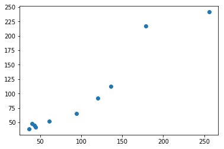

```python
import matplotlib.pyplot as plot
print(y_test)
predictions = regression_model.predict(X_test);
plot.scatter(y_test,predictions)
print(predictions)
```

# Question 14 - Evaluation of model with scikit-learn

Validate the model with Root Mean Squares error and R^2 score using scikit-learn. RMSE and R2 for test data and prediction

Hint: You can import mean_squared_error function & r2 (R square) from sklearn.metrics. Performing root operation over mean square error over mean square error gives you root mean square error

```python
from sklearn.metrics import mean_squared_error
from sklearn.metrics import r2_score
RMSE = mean_squared_error(y_test,predictions)
import math
print(math.sqrt(RMSE))
r2= r2_score(y_test,predictions)
print(r2)
```

```
19.97968883940179
0.9166672652137311
```

## Question 15 - Calculate the accuracy of the model for both training and test data set

### Hint: .score() function

```python
regression_model.score(X_test,y_test)
```

```
0.9166672652137311
```

```python
regression_model.score(X_train,y_train)
```

```
0.966795288692784
```